# examples_0203

- Valid:
- Extraneous:

You should be able to complete the picture. Use symmetry to complete the parabola, and use the slope to extend the line.

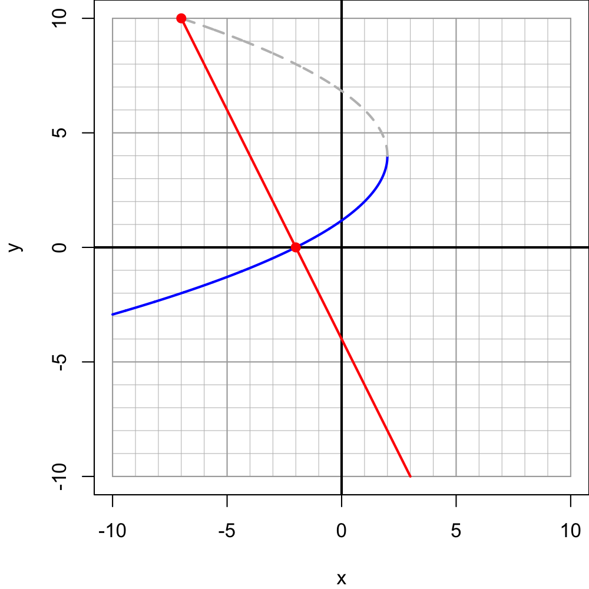

The intersection of the line with the valid half of the parabola is at point $(-2,0)$. Thus the valid solution is $x=-2$.

The intersection of the line with the extraneous half of the parabola is at point $(-7,10)$. Thus the extraneous solution is $x=-7$.

A transformed square-root function, $y=f(x)$, is graphed below. A linear function, $y=L(x)$, is not shown, but it goes through point $(8,-1)$ and has a slope of $-2$.

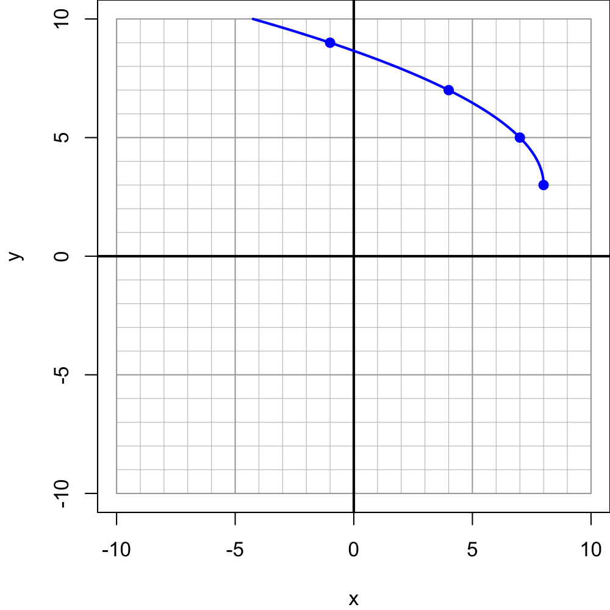

If standard algebraic steps were used to find $x$ values that satisfy equation $f(x)=L(x)$, what valid solution and what extraneous solution would be found?

- Valid:
- Extraneous:

You should be able to complete the picture. Use symmetry to complete the parabola, and use the slope to extend the line.

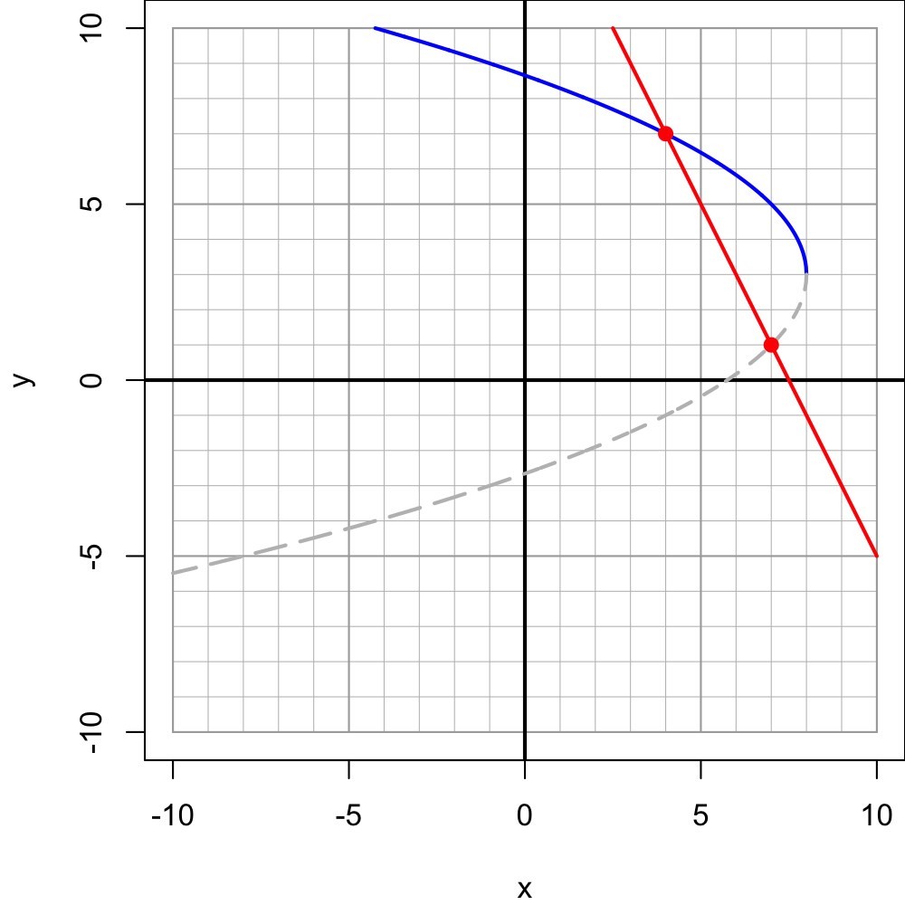

The intersection of the line with the valid half of the parabola is at point $(4,7)$. Thus the valid solution is $x=4$.

The intersection of the line with the extraneous half of the parabola is at point $(7,1)$. Thus the extraneous solution is $x=7$.

A transformed square-root function, $y=f(x)$, is graphed below. A linear function, $y=L(x)$, is not shown, but it goes through point $(4,7)$ and has a slope of $1$.

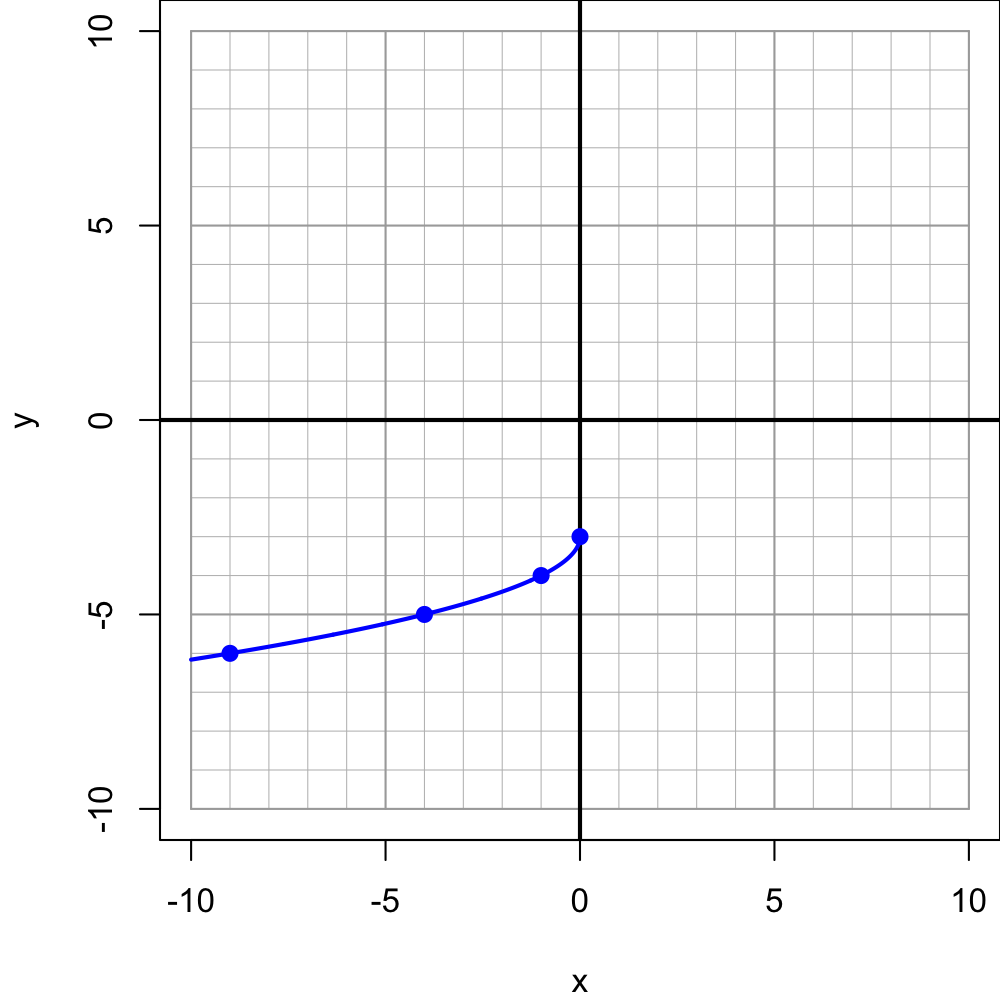

If standard algebraic steps were used to find $x$ values that satisfy equation $f(x)=L(x)$, what valid solution and what extraneous solution would be found?

- Valid:
- Extraneous:

You should be able to complete the picture. Use symmetry to complete the parabola, and use the slope to extend the line.

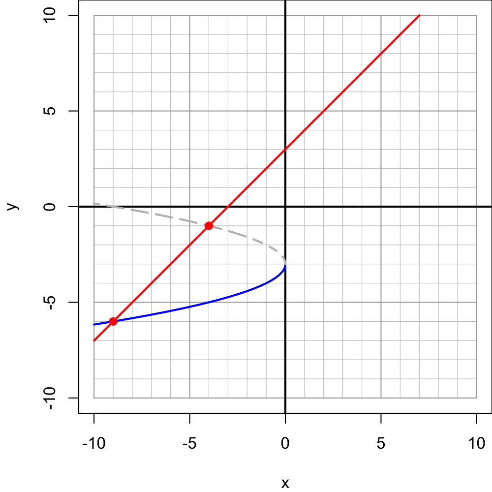

The intersection of the line with the valid half of the parabola is at point $(-9,-6)$. Thus the valid solution is $x=-9$.

The intersection of the line with the extraneous half of the parabola is at point $(-4,-1)$. Thus the extraneous solution is $x=-4$.

A transformed square-root function, $y=f(x)$, is graphed below. A linear function, $y=L(x)$, is not shown, but it goes through point $(0,3)$ and has a slope of $1$.

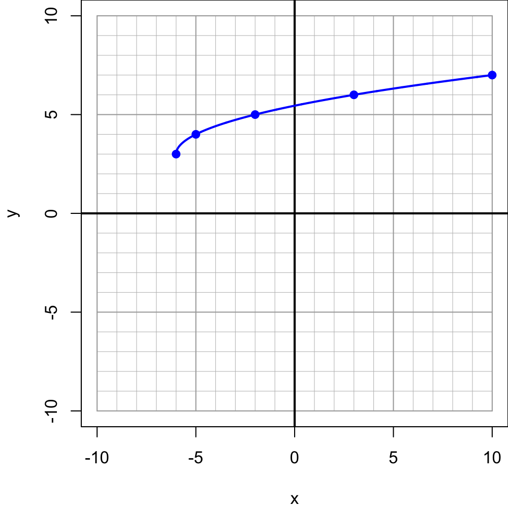

If standard algebraic steps were used to find $x$ values that satisfy equation $f(x)=L(x)$, what valid solution and what extraneous solution would be found?

- Valid:
- Extraneous:

You should be able to complete the picture. Use symmetry to complete the parabola, and use the slope to extend the line.

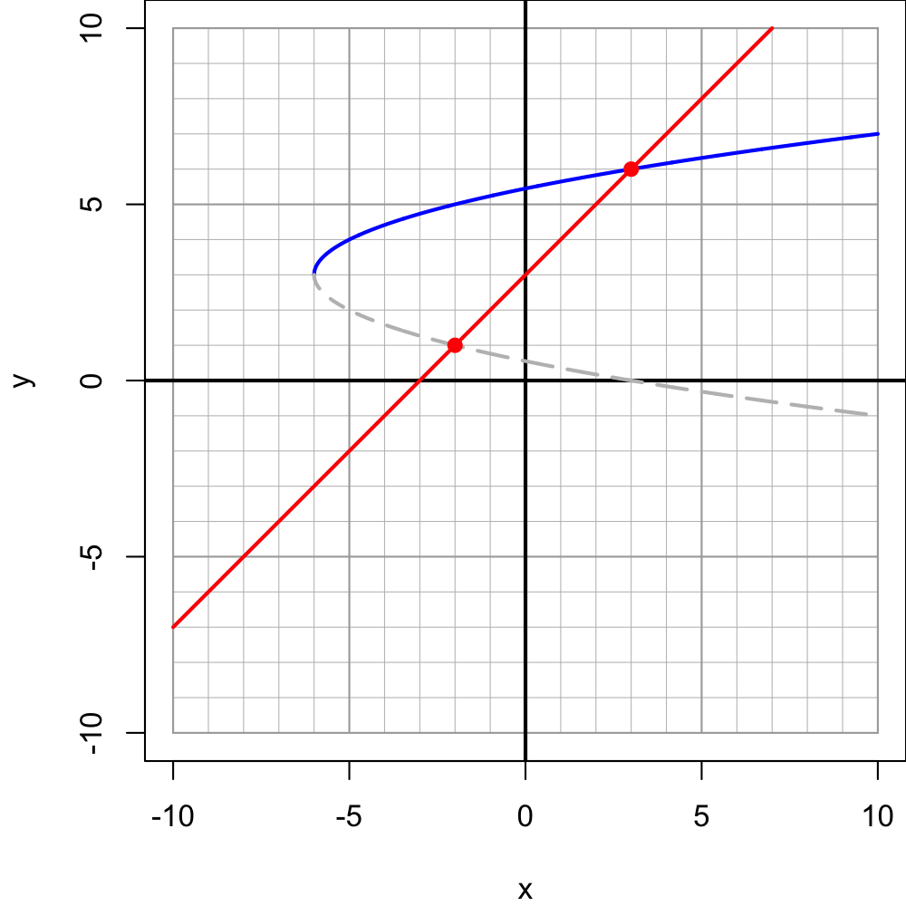

The intersection of the line with the valid half of the parabola is at point $(3,6)$. Thus the valid solution is $x=3$.

The intersection of the line with the extraneous half of the parabola is at point $(-2,1)$. Thus the extraneous solution is $x=-2$.

A transformed square-root function, $y=f(x)$, is graphed below. A linear function, $y=L(x)$, is not shown, but it goes through point $(1,-7)$ and has a slope of $\frac{3}{2}$.

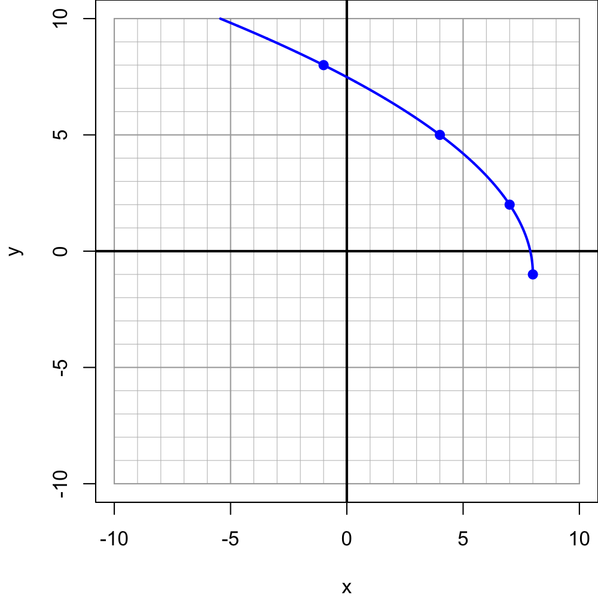

If standard algebraic steps were used to find $x$ values that satisfy equation $f(x)=L(x)$, what valid solution and what extraneous solution would be found?

- Valid:
- Extraneous:

You should be able to complete the picture. Use symmetry to complete the parabola, and use the slope to extend the line.

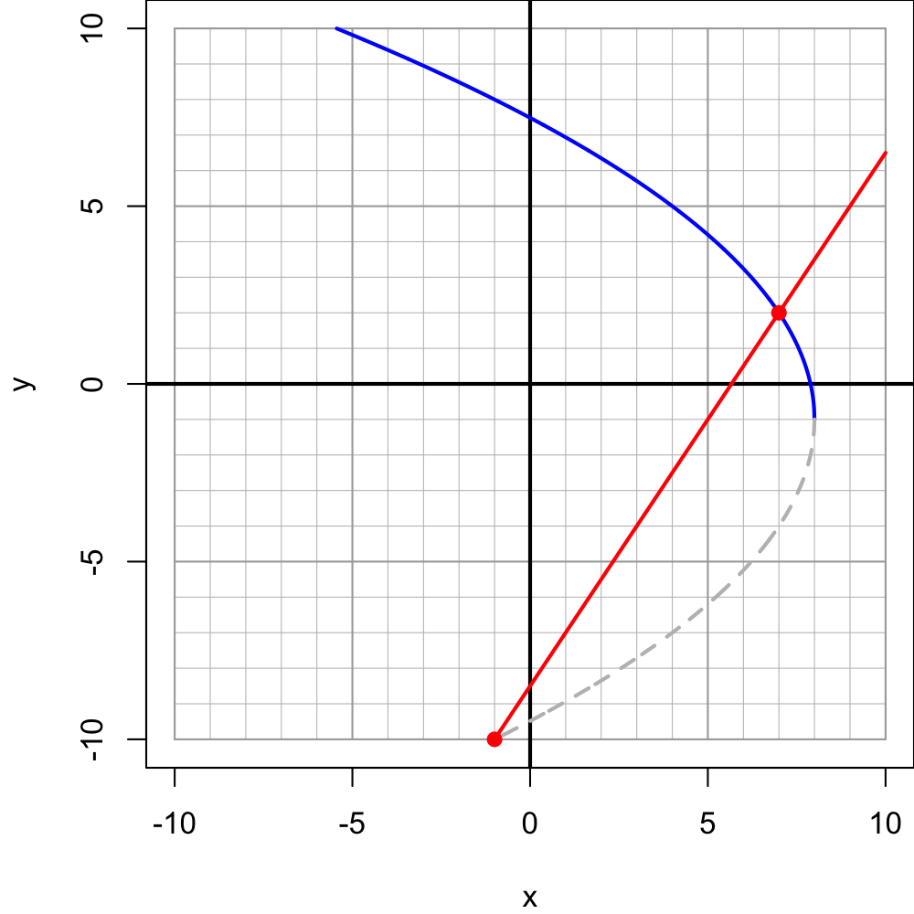

The intersection of the line with the valid half of the parabola is at point $(7,2)$. Thus the valid solution is $x=7$.

The intersection of the line with the extraneous half of the parabola is at point $(-1,-10)$. Thus the extraneous solution is $x=-1$.

A transformed square-root function, $y=f(x)$, is graphed below. A linear function, $y=L(x)$, is not shown, but it goes through point $(9,0)$ and has a slope of $\frac{2}{3}$.

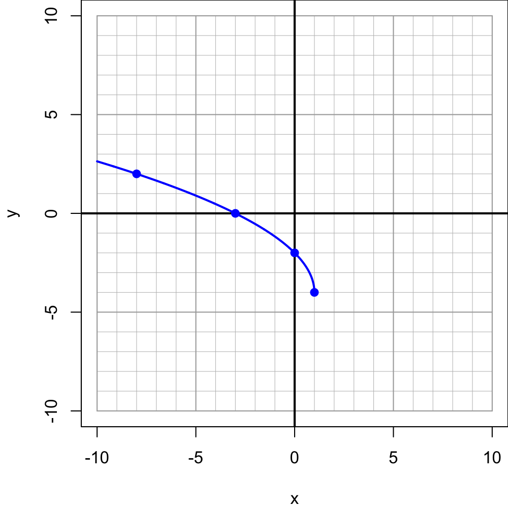

If standard algebraic steps were used to find $x$ values that satisfy equation $f(x)=L(x)$, two possible solutions $x_1$ and $x_2$ will be found such that $x_1<x_2$. Determine the possible solutions, and check if each is valid or extraneous.

- $x_1=$
- $x_1$ is solution
- $x_2=$
- $x_2$ is solution

You should be able to complete the picture. Use symmetry to complete the parabola, and use the slope to extend the line.

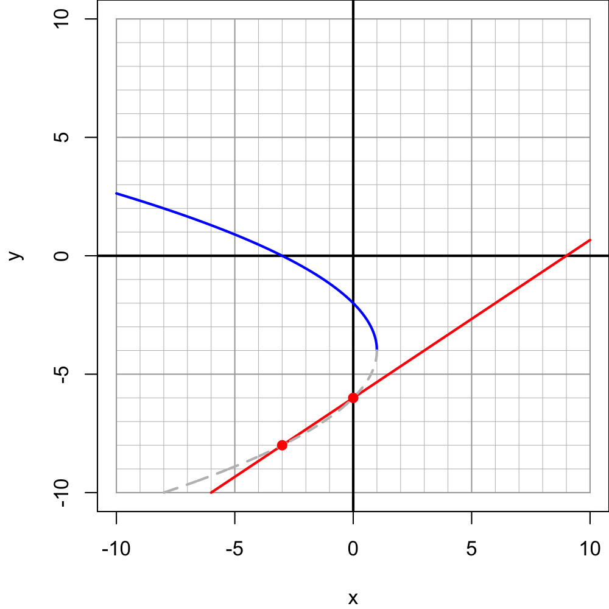

The intersection further left is at $x_1=-3$ and it is an extraneous solution.

The intersection further right is at $x_2=0$ and it is an extraneous solution.

I'll also mention that you could solve approach this problem algebraically. First, examine curve $y=f(x)$ to find the transformations. From those transformations, you can write an algebraic definition of $f(x)$.

$$f(x)=-4+2\sqrt{-x+1}$$

To write an algebraic definition of $L(x)$, use point-slope form.

$$L(x)=\frac{2}{3}(x-9)+0$$

Then set up the equation to solve.

$$-4+2\sqrt{-x+1}=\frac{2}{3}(x-9)+0$$

By doing the algebraic manipulations, you'll find two possible solutions: $x_1=-3$ and $x_2=0$. If you test each in the equation, you'll find that $x=-3$ is an extraneous solution, and $x=0$ is an extraneous solution.

A transformed square-root function, $y=f(x)$, is graphed below. A linear function, $y=L(x)$, is not shown, but it goes through point $(-4,1)$ and has a slope of $\frac{1}{2}$.

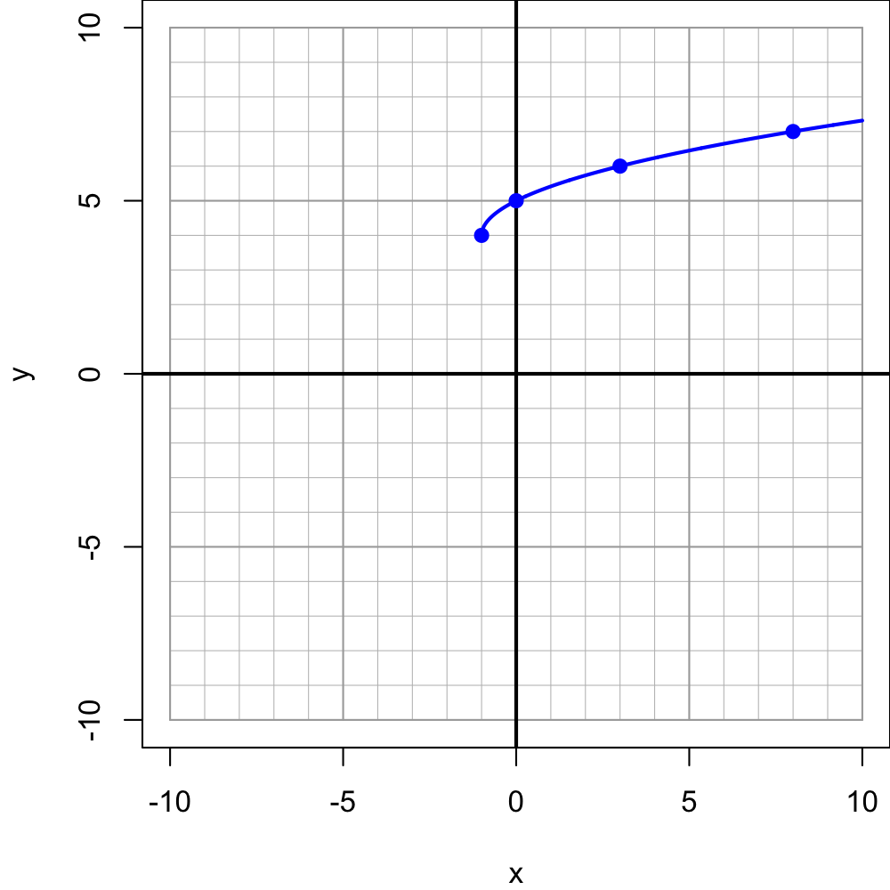

If standard algebraic steps were used to find $x$ values that satisfy equation $f(x)=L(x)$, two possible solutions $x_1$ and $x_2$ will be found such that $x_1<x_2$. Determine the possible solutions, and check if each is valid or extraneous.

- $x_1=$
- $x_1$ is solution
- $x_2=$
- $x_2$ is solution

You should be able to complete the picture. Use symmetry to complete the parabola, and use the slope to extend the line.

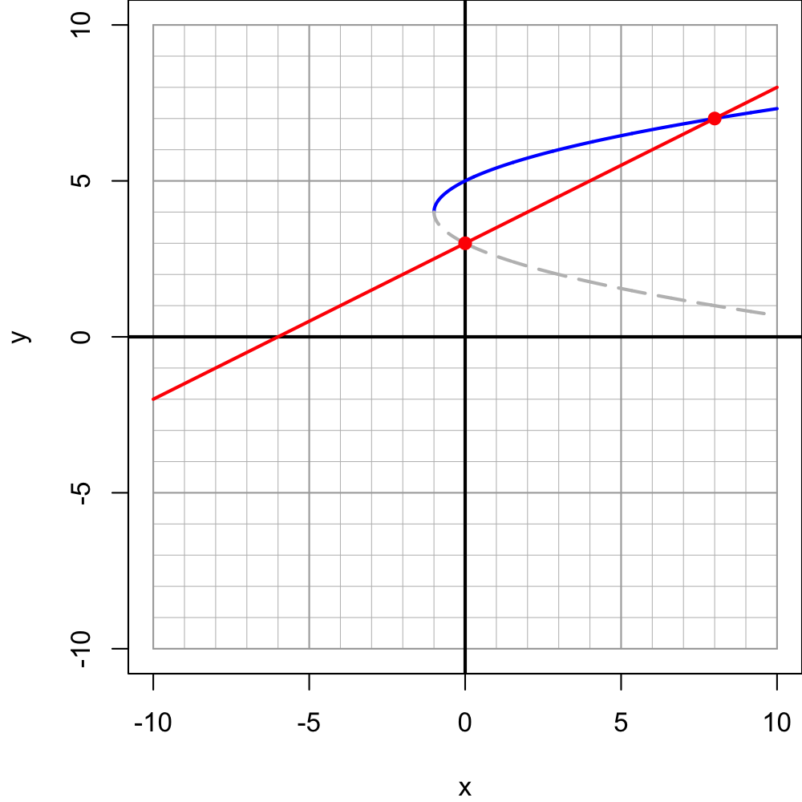

The intersection further left is at $x_1=0$ and it is an extraneous solution.

The intersection further right is at $x_2=8$ and it is a valid solution.

I'll also mention that you could solve approach this problem algebraically. First, examine curve $y=f(x)$ to find the transformations. From those transformations, you can write an algebraic definition of $f(x)$.

$$f(x)=4+1\sqrt{x+1}$$

To write an algebraic definition of $L(x)$, use point-slope form.

$$L(x)=\frac{1}{2}(x+4)+1$$

Then set up the equation to solve.

$$4+1\sqrt{x+1}=\frac{1}{2}(x+4)+1$$

By doing the algebraic manipulations, you'll find two possible solutions: $x_1=0$ and $x_2=8$. If you test each in the equation, you'll find that $x=0$ is an extraneous solution, and $x=8$ is a valid solution.

A transformed square-root function, $y=f(x)$, is graphed below. A linear function, $y=L(x)$, is not shown, but it goes through point $(7,-2)$ and has a slope of $-1$.

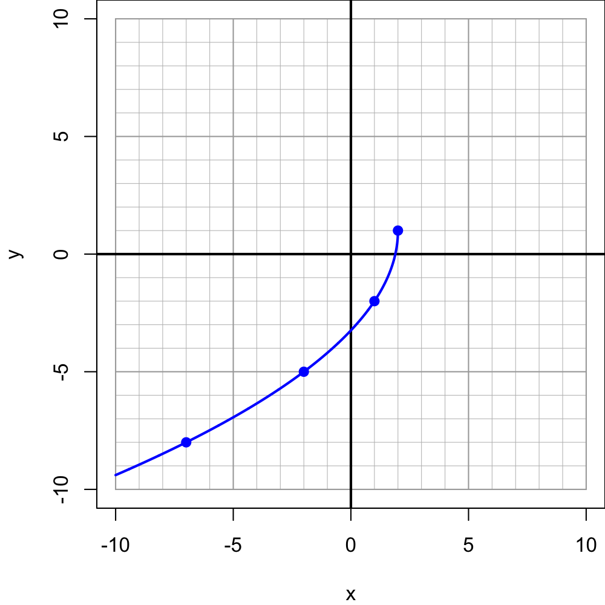

If standard algebraic steps were used to find $x$ values that satisfy equation $f(x)=L(x)$, two possible solutions $x_1$ and $x_2$ will be found such that $x_1<x_2$. Determine the possible solutions, and check if each is valid or extraneous.

- $x_1=$
- $x_1$ is solution
- $x_2=$
- $x_2$ is solution

You should be able to complete the picture. Use symmetry to complete the parabola, and use the slope to extend the line.

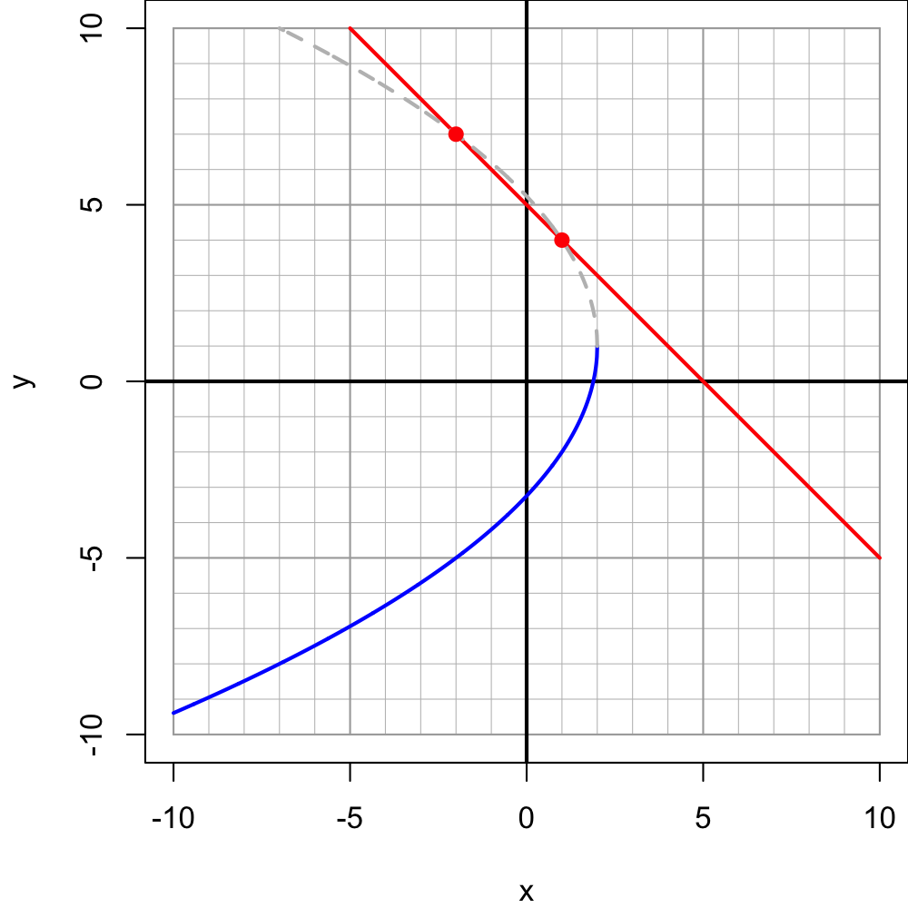

The intersection further left is at $x_1=-2$ and it is an extraneous solution.

The intersection further right is at $x_2=1$ and it is an extraneous solution.

I'll also mention that you could solve approach this problem algebraically. First, examine curve $y=f(x)$ to find the transformations. From those transformations, you can write an algebraic definition of $f(x)$.

$$f(x)=1-3\sqrt{-x+2}$$

To write an algebraic definition of $L(x)$, use point-slope form.

$$L(x)=-1(x-7)-2$$

Then set up the equation to solve.

$$1-3\sqrt{-x+2}=-1(x-7)-2$$

By doing the algebraic manipulations, you'll find two possible solutions: $x_1=-2$ and $x_2=1$. If you test each in the equation, you'll find that $x=-2$ is an extraneous solution, and $x=1$ is an extraneous solution.

A transformed square-root function, $y=f(x)$, is graphed below. A linear function, $y=L(x)$, is not shown, but it goes through point $(-1,6)$ and has a slope of $1$.

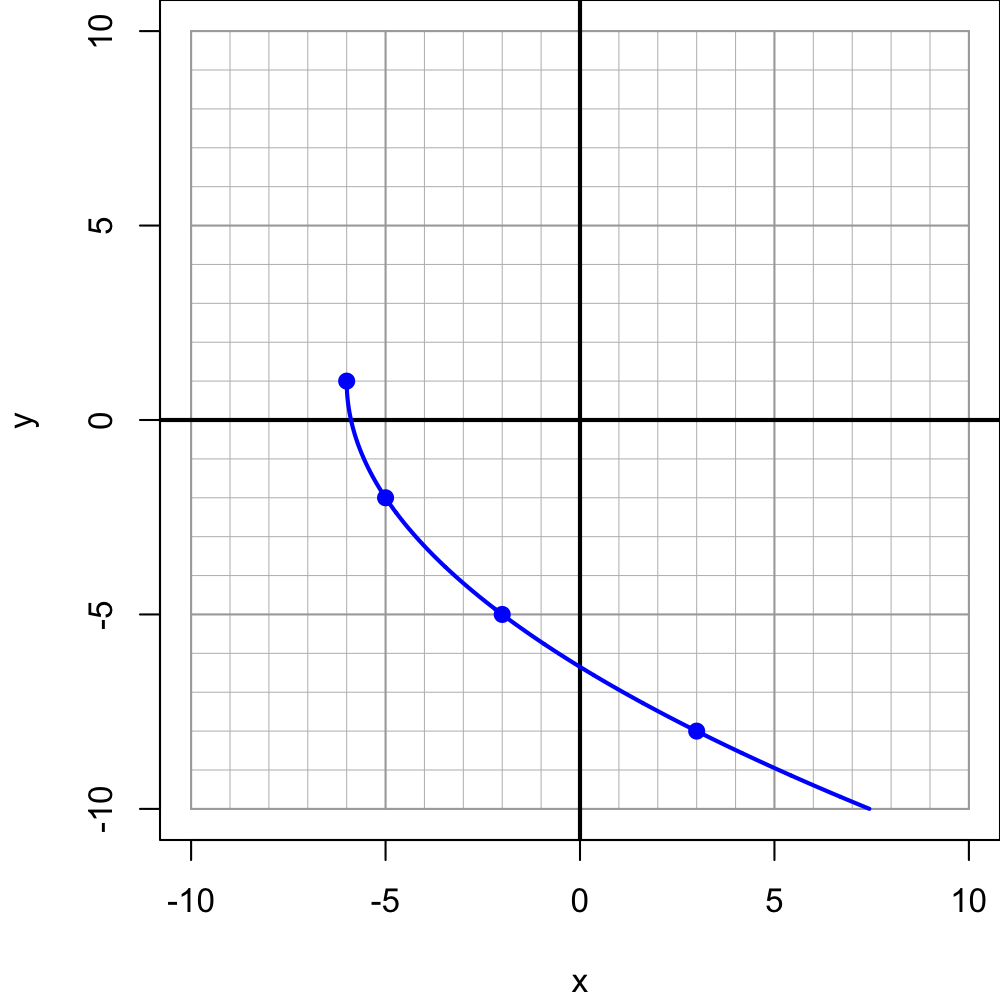

If standard algebraic steps were used to find $x$ values that satisfy equation $f(x)=L(x)$, two possible solutions $x_1$ and $x_2$ will be found such that $x_1<x_2$. Determine the possible solutions, and check if each is valid or extraneous.

- $x_1=$
- $x_1$ is solution
- $x_2=$
- $x_2$ is solution

You should be able to complete the picture. Use symmetry to complete the parabola, and use the slope to extend the line.

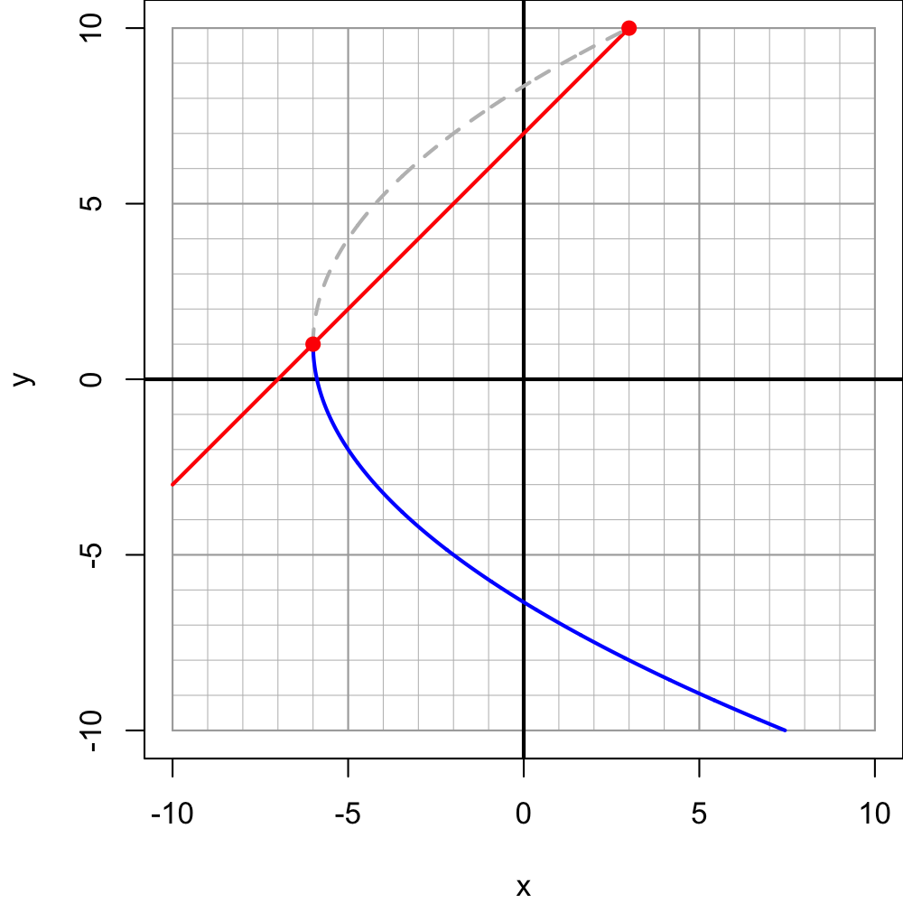

The intersection further left is at $x_1=-6$ and it is a valid solution.

The intersection further right is at $x_2=3$ and it is an extraneous solution.

I'll also mention that you could solve approach this problem algebraically. First, examine curve $y=f(x)$ to find the transformations. From those transformations, you can write an algebraic definition of $f(x)$.

$$f(x)=1-3\sqrt{x+6}$$

To write an algebraic definition of $L(x)$, use point-slope form.

$$L(x)=1(x+1)+6$$

Then set up the equation to solve.

$$1-3\sqrt{x+6}=1(x+1)+6$$

By doing the algebraic manipulations, you'll find two possible solutions: $x_1=-6$ and $x_2=3$. If you test each in the equation, you'll find that $x=-6$ is a valid solution, and $x=3$ is an extraneous solution.

A transformed square-root function, $y=f(x)$, is graphed below. A linear function, $y=L(x)$, is not shown, but it goes through point $(7,8)$ and has a slope of $\frac{1}{4}$.

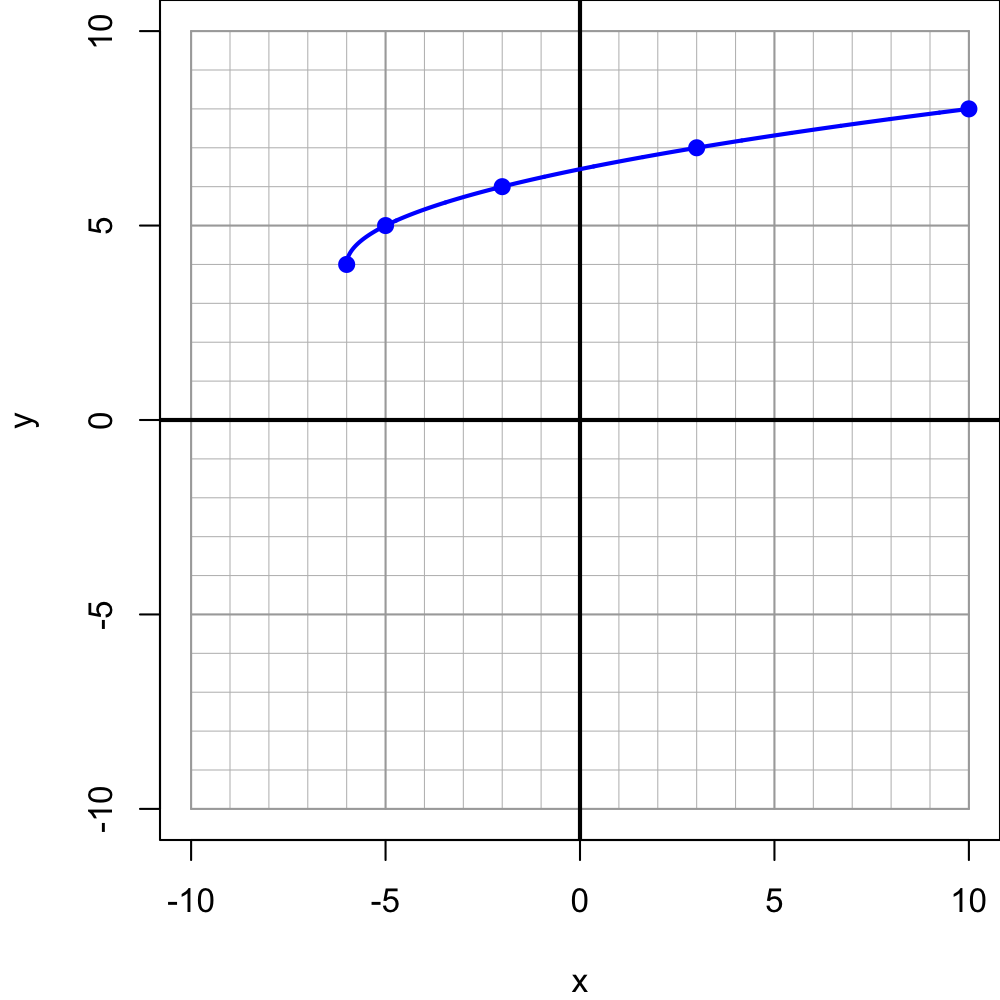

If standard algebraic steps were used to find $x$ values that satisfy equation $f(x)=L(x)$, two possible solutions $x_1$ and $x_2$ will be found such that $x_1<x_2$. Determine the possible solutions, and check if each is valid or extraneous.

- $x_1=$
- $x_1$ is solution
- $x_2=$
- $x_2$ is solution

You should be able to complete the picture. Use symmetry to complete the parabola, and use the slope to extend the line.

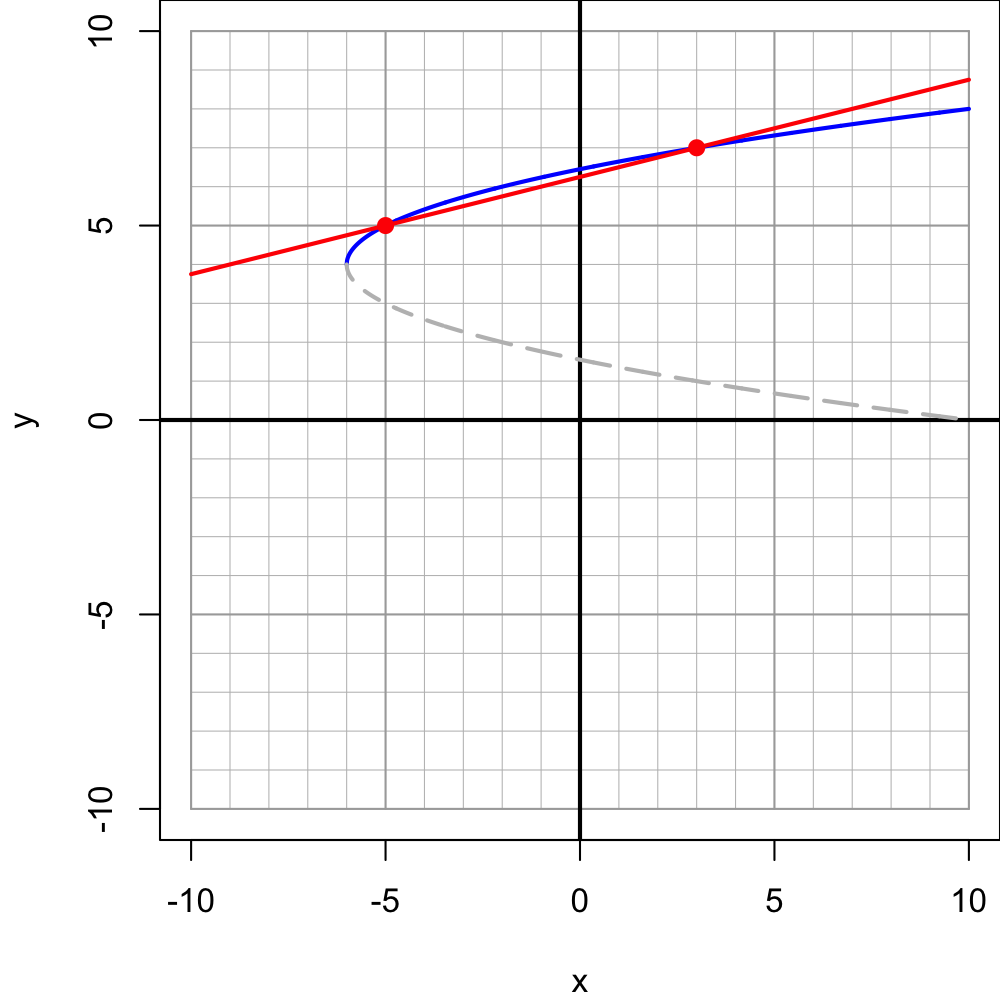

The intersection further left is at $x_1=-5$ and it is a valid solution.

The intersection further right is at $x_2=3$ and it is a valid solution.

I'll also mention that you could solve approach this problem algebraically. First, examine curve $y=f(x)$ to find the transformations. From those transformations, you can write an algebraic definition of $f(x)$.

$$f(x)=4+1\sqrt{x+6}$$

To write an algebraic definition of $L(x)$, use point-slope form.

$$L(x)=\frac{1}{4}(x-7)+8$$

Then set up the equation to solve.

$$4+1\sqrt{x+6}=\frac{1}{4}(x-7)+8$$

By doing the algebraic manipulations, you'll find two possible solutions: $x_1=-5$ and $x_2=3$. If you test each in the equation, you'll find that $x=-5$ is a valid solution, and $x=3$ is a valid solution.

A transformed square-root function, $y=f(x)$, is graphed below. A linear function, $y=L(x)$, is not shown, but it goes through point $(8,-5)$ and has a slope of $\frac{-1}{2}$.

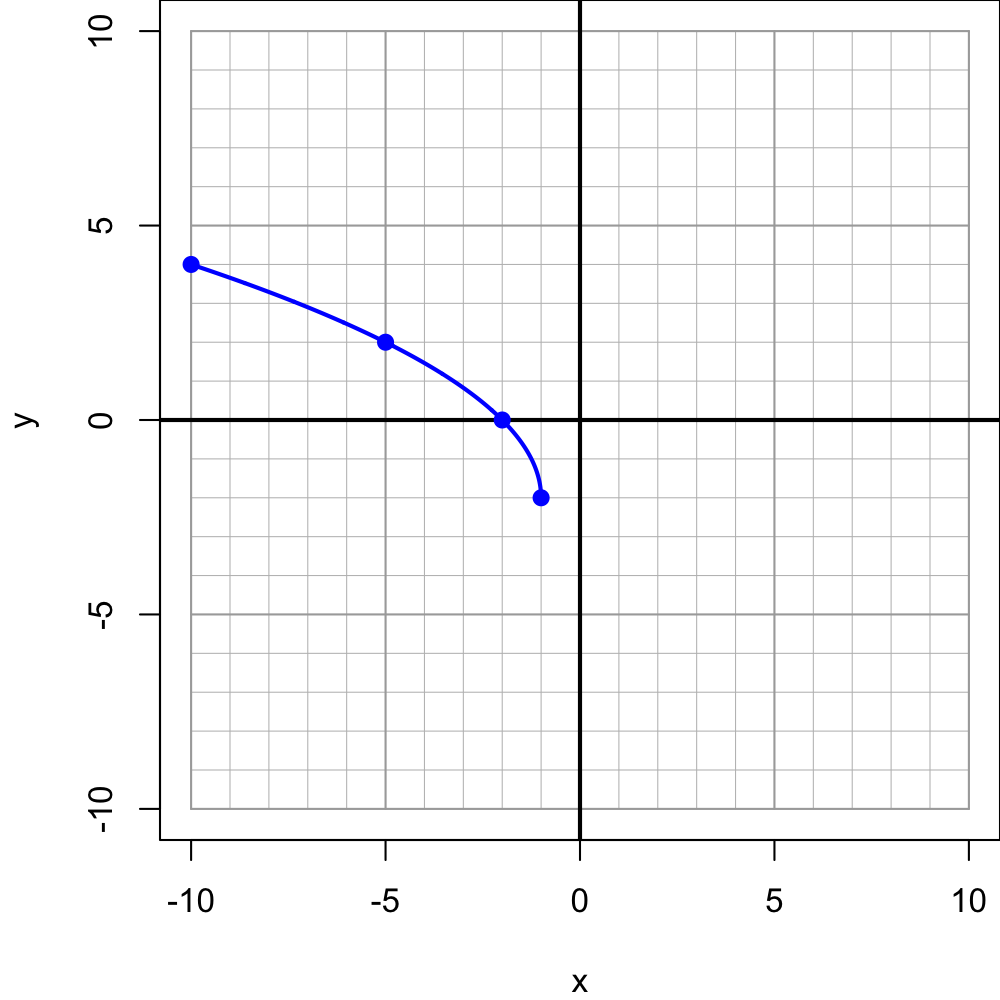

If standard algebraic steps were used to find $x$ values that satisfy equation $f(x)=L(x)$, two possible solutions $x_1$ and $x_2$ will be found such that $x_1<x_2$. Determine the possible solutions, and check if each is valid or extraneous.

- $x_1=$
- $x_1$ is solution
- $x_2=$
- $x_2$ is solution

You should be able to complete the picture. Use symmetry to complete the parabola, and use the slope to extend the line.

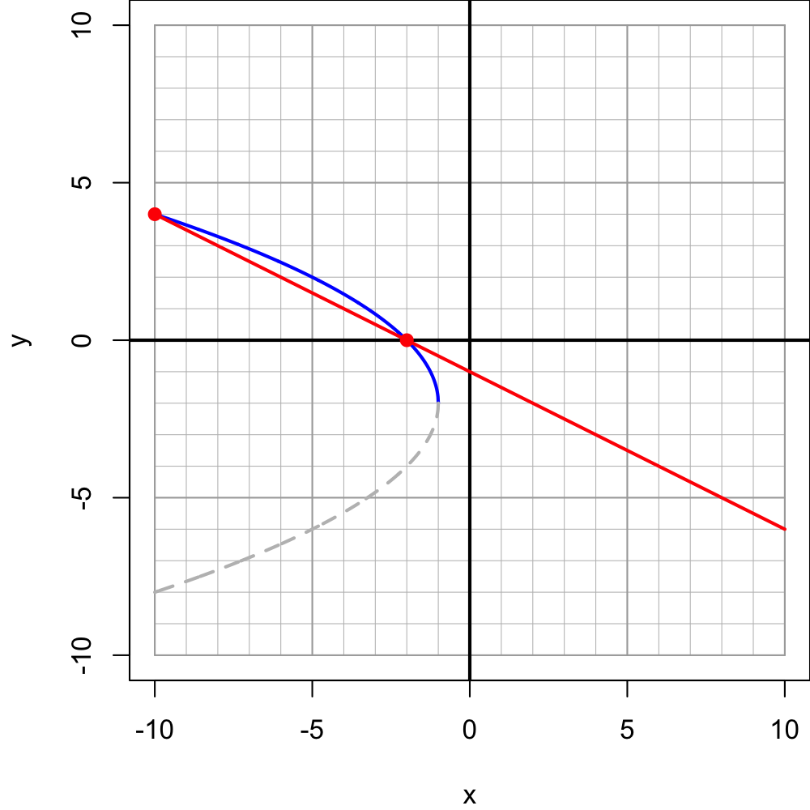

The intersection further left is at $x_1=-10$ and it is a valid solution.

The intersection further right is at $x_2=-2$ and it is a valid solution.

I'll also mention that you could solve approach this problem algebraically. First, examine curve $y=f(x)$ to find the transformations. From those transformations, you can write an algebraic definition of $f(x)$.

$$f(x)=-2+2\sqrt{-x-1}$$

To write an algebraic definition of $L(x)$, use point-slope form.

$$L(x)=\frac{-1}{2}(x-8)-5$$

Then set up the equation to solve.

$$-2+2\sqrt{-x-1}=\frac{-1}{2}(x-8)-5$$

By doing the algebraic manipulations, you'll find two possible solutions: $x_1=-10$ and $x_2=-2$. If you test each in the equation, you'll find that $x=-10$ is a valid solution, and $x=-2$ is a valid solution.

A transformed square-root function, $y=f(x)$, is graphed below. A linear function, $y=L(x)$, is not shown, but it goes through point $(-1,-6)$ and has a slope of $\frac{-1}{3}$.

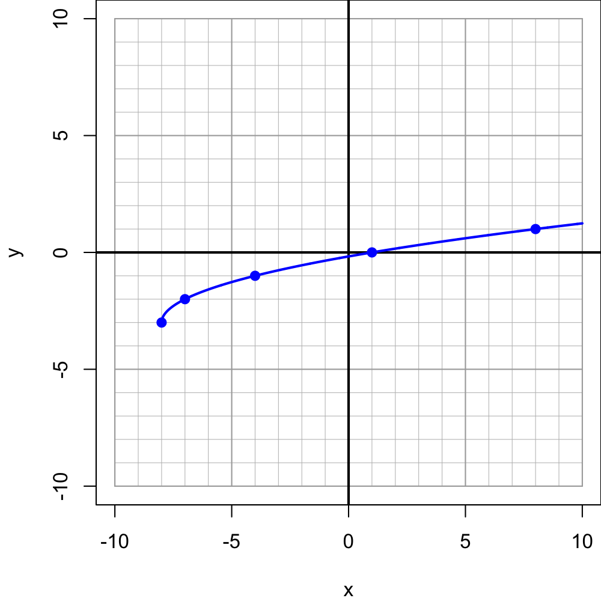

If standard algebraic steps were used to find $x$ values that satisfy equation $f(x)=L(x)$, two possible solutions $x_1$ and $x_2$ will be found such that $x_1<x_2$. Determine the possible solutions, and check if each is valid or extraneous.

- $x_1=$
- $x_1$ is solution
- $x_2=$
- $x_2$ is solution

You should be able to complete the picture. Use symmetry to complete the parabola, and use the slope to extend the line.

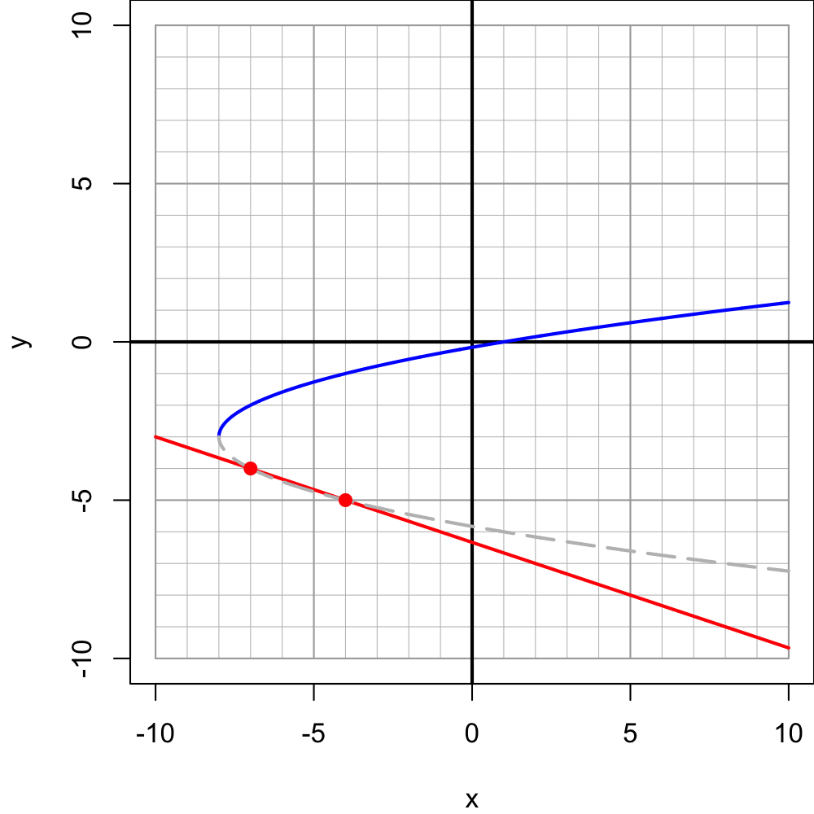

The intersection further left is at $x_1=-7$ and it is an extraneous solution.

The intersection further right is at $x_2=-4$ and it is an extraneous solution.

I'll also mention that you could solve approach this problem algebraically. First, examine curve $y=f(x)$ to find the transformations. From those transformations, you can write an algebraic definition of $f(x)$.

$$f(x)=-3+1\sqrt{x+8}$$

To write an algebraic definition of $L(x)$, use point-slope form.

$$L(x)=\frac{-1}{3}(x+1)-6$$

Then set up the equation to solve.

$$-3+1\sqrt{x+8}=\frac{-1}{3}(x+1)-6$$

By doing the algebraic manipulations, you'll find two possible solutions: $x_1=-7$ and $x_2=-4$. If you test each in the equation, you'll find that $x=-7$ is an extraneous solution, and $x=-4$ is an extraneous solution.

A transformed square-root function, $y=f(x)$, is graphed below. A linear function, $y=L(x)$, is not shown, but it goes through point $(0,-2)$ and has a slope of $\frac{1}{5}$.

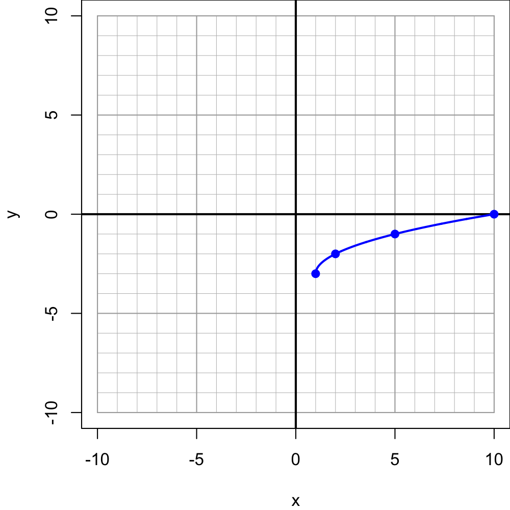

If standard algebraic steps were used to find $x$ values that satisfy equation $f(x)=L(x)$, two possible solutions $x_1$ and $x_2$ will be found such that $x_1<x_2$. Determine the possible solutions, and check if each is valid or extraneous.

- $x_1=$
- $x_1$ is solution
- $x_2=$
- $x_2$ is solution

You should be able to complete the picture. Use symmetry to complete the parabola, and use the slope to extend the line.

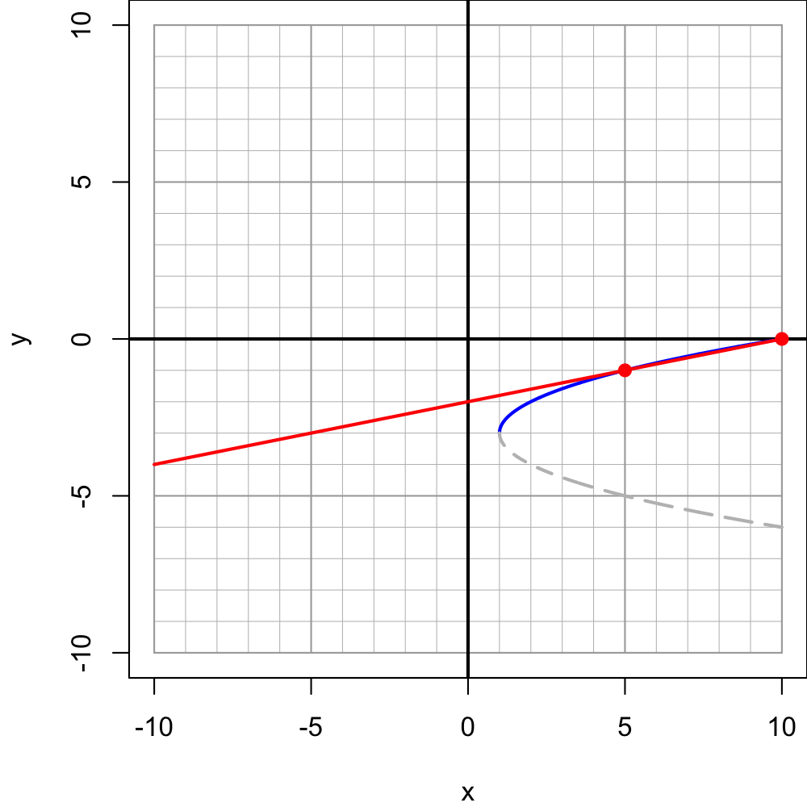

The intersection further left is at $x_1=5$ and it is a valid solution.

The intersection further right is at $x_2=10$ and it is a valid solution.

I'll also mention that you could solve approach this problem algebraically. First, examine curve $y=f(x)$ to find the transformations. From those transformations, you can write an algebraic definition of $f(x)$.

$$f(x)=-3+1\sqrt{x-1}$$

To write an algebraic definition of $L(x)$, use point-slope form.

$$L(x)=\frac{1}{5}(x+0)-2$$

Then set up the equation to solve.

$$-3+1\sqrt{x-1}=\frac{1}{5}(x+0)-2$$

By doing the algebraic manipulations, you'll find two possible solutions: $x_1=5$ and $x_2=10$. If you test each in the equation, you'll find that $x=5$ is a valid solution, and $x=10$ is a valid solution.

A transformed square-root function, $y=f(x)$, is graphed below. A linear function, $y=L(x)$, is not shown, but it goes through point $(-2,1)$ and has a slope of $2$.

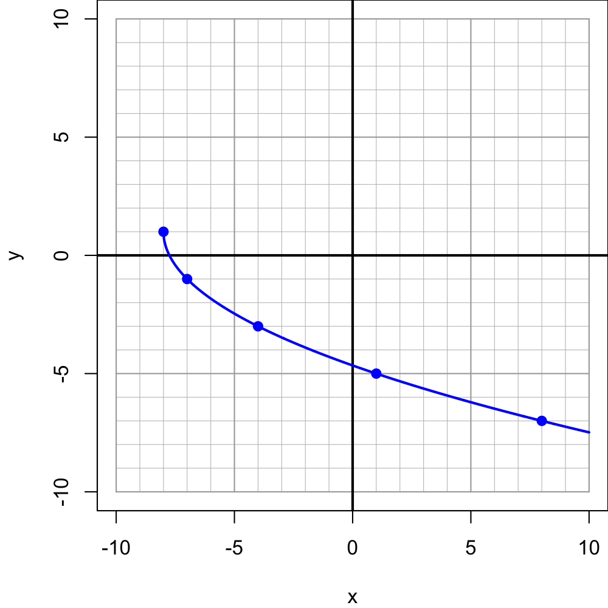

If standard algebraic steps were used to find $x$ values that satisfy equation $f(x)=L(x)$, two possible solutions $x_1$ and $x_2$ will be found such that $x_1<x_2$. Determine the possible solutions, and check if each is valid or extraneous.

- $x_1=$
- $x_1$ is solution
- $x_2=$
- $x_2$ is solution

You should be able to complete the picture. Use symmetry to complete the parabola, and use the slope to extend the line.

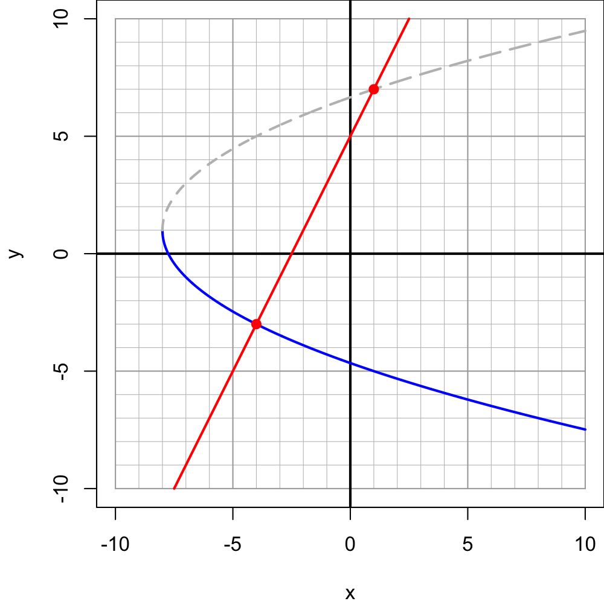

The intersection further left is at $x_1=-4$ and it is a valid solution.

The intersection further right is at $x_2=1$ and it is an extraneous solution.

I'll also mention that you could solve approach this problem algebraically. First, examine curve $y=f(x)$ to find the transformations. From those transformations, you can write an algebraic definition of $f(x)$.

$$f(x)=1-2\sqrt{x+8}$$

To write an algebraic definition of $L(x)$, use point-slope form.

$$L(x)=2(x+2)+1$$

Then set up the equation to solve.

$$1-2\sqrt{x+8}=2(x+2)+1$$

By doing the algebraic manipulations, you'll find two possible solutions: $x_1=-4$ and $x_2=1$. If you test each in the equation, you'll find that $x=-4$ is a valid solution, and $x=1$ is an extraneous solution.

A transformed square-root function, $y=f(x)$, is graphed below. A linear function, $y=L(x)$, is not shown, but it goes through point $(-9,9)$ and has a slope of $\frac{-2}{3}$.

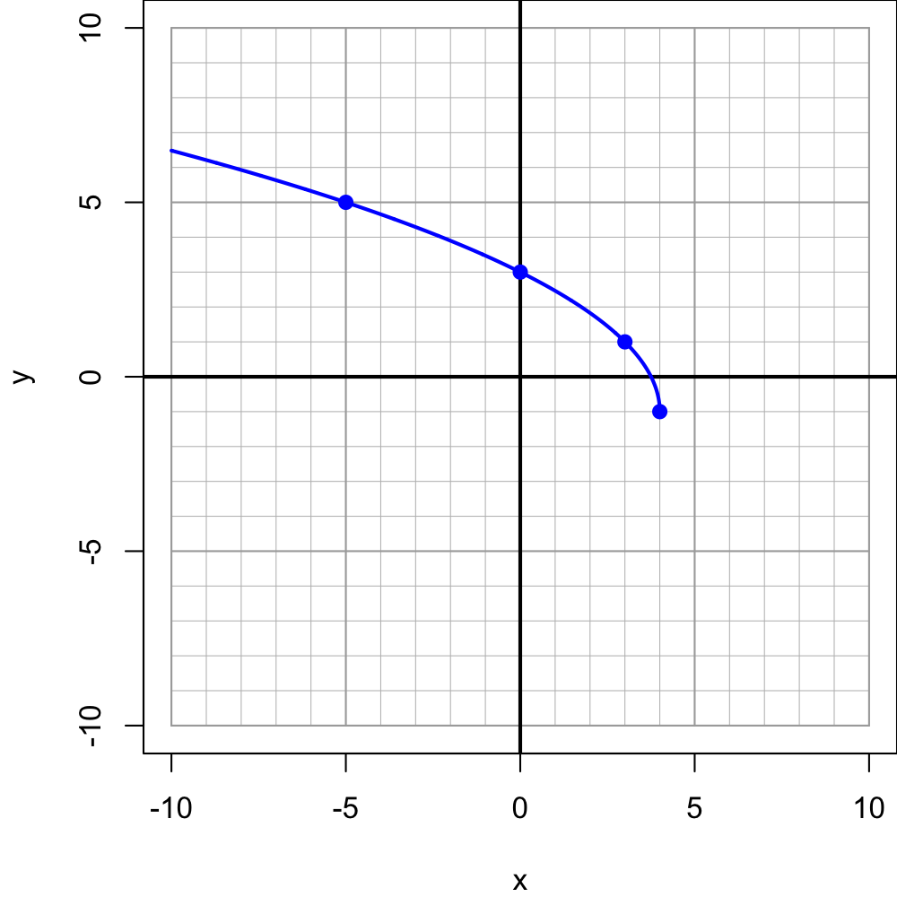

If standard algebraic steps were used to find $x$ values that satisfy equation $f(x)=L(x)$, two possible solutions $x_1$ and $x_2$ will be found such that $x_1<x_2$. Determine the possible solutions, and check if each is valid or extraneous.

- $x_1=$
- $x_1$ is solution
- $x_2=$
- $x_2$ is solution

You should be able to complete the picture. Use symmetry to complete the parabola, and use the slope to extend the line.

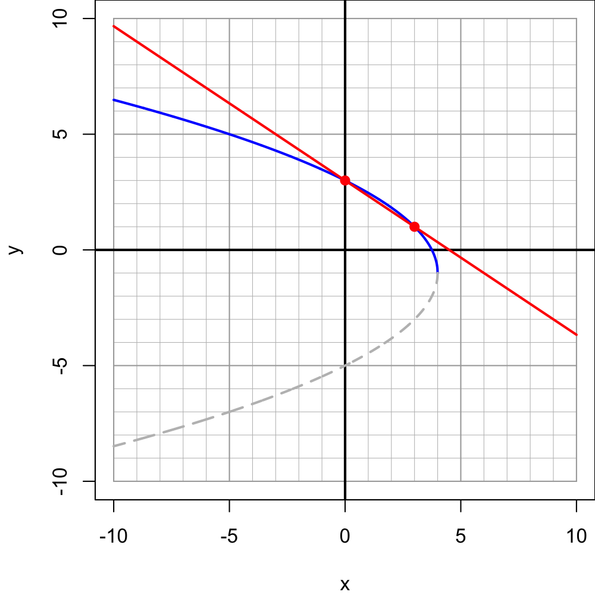

The intersection further left is at $x_1=0$ and it is a valid solution.

The intersection further right is at $x_2=3$ and it is a valid solution.

I'll also mention that you could solve approach this problem algebraically. First, examine curve $y=f(x)$ to find the transformations. From those transformations, you can write an algebraic definition of $f(x)$.

$$f(x)=-1+2\sqrt{-x+4}$$

To write an algebraic definition of $L(x)$, use point-slope form.

$$L(x)=\frac{-2}{3}(x+9)+9$$

Then set up the equation to solve.

$$-1+2\sqrt{-x+4}=\frac{-2}{3}(x+9)+9$$

By doing the algebraic manipulations, you'll find two possible solutions: $x_1=0$ and $x_2=3$. If you test each in the equation, you'll find that $x=0$ is a valid solution, and $x=3$ is a valid solution.